# Geog533 Lab 9

Xiaoxu Pan

Complete the following exercises in Chapter 9 (More on Regression) of the textbook pages 286-287.

## Question 1

This is Exercise 7 in Chapter 9 of the Textbook [R].

### Question 1(a)

Fill in the blanks.

```r
TSS <- 4234+3487
n <- 14
Tdf <- n-1
df2 <- n-1-3
RGMS <- 4234/3
RSMS <- 3487/df2
F <- RGMS/RSMS
```

|  | Sum of squares | Degrees of freedom | Mean square | *F* |
| --- | --- | --- | --- | --- |
| Regression SS | 4234 | 3 | 1411.3333333 | 4.0474142 |
| Residual SS | 3487 | 10 | 348.7 |  |
| Total SS | 7721 | 13 |  |  |

### Question 1(b)

What is the value of $r^2$?

```r
Mr <- 4234/TSS
Mr
```

```
[1] 0.5483746
```

### Question 1(c)

What is the standard error of the estimate?

```r
e <- sqrt(RSMS)
e
```

```
[1] 18.67351
```

### Question 1(d)

Test the null hypothesis that $R^2 = 0$ by comparing the $F-statistic$ from the table with its critical value.

```r
f.critical <- qf(0.95,3,10)
if(F>f.critical){
  print("R^2 is not equal to 0")
}else{
  print("R^2 is equal to 0")
}
```

```
[1] "R^2 is not equal to 0"
```

### Question 1(e)

Are the coefficients in the direction you would hypothesize? If not, which coefficients are opposite in sign from what you would expect?

```r
print("The coefficients of median family income and size of house are in the right direction because more income or larger size of house, higher house price. But the coefficient of size of lot is not in the right direction. I expect that the bigger size of lot the higher housing price ")
```

```
[1] "The coefficients of median family income and size of house are in the right direction because more income or larger size of house, higher house price. But the coefficient of size of lot is not in the right direction. I expect that the bigger size of lot the higher housing price "
```

### Question 1(f)

```r
#r <- sqrt(4234/TSS)
n <- 14
t1.statistics <- 1.57/0.34
t2.statistics <- 23.4/11.2
t3.statistics <- -9.5/7.1
t.critical <- qt(0.975,df = n-1)
t1.critical <- qt(0.025,df = n-1)
if(t1.statistics>t.critical){
  print("The coefficients of Median family income is not equal to zero")
}else{
  print("The coefficients of Median family income is equal to zero")
}
```

```
[1] "The coefficients of Median family income is not equal to zero"
```

```r
if(t2.statistics>t.critical){
  print("The coefficients of Size of house is not equal to zero")
}else{
  print("The coefficients of Size of house is equal to zero")
}
```

```
[1] "The coefficients of Size of house is equal to zero"
```

```r
if(t3.statistics<t1.critical){
  print("The coefficients of Size of lot is not equal to zero")
}else{
  print("The coefficients of Size of lot is equal to zero")
}
```

```
[1] "The coefficients of Size of lot is equal to zero"
```

### Question 1(g)

What do you conclude from the variance inflation factors (VIFs)? What (if any) modifications would you recommend in light of the VIFs?

```r
print("Median family income and size of house do not have potential multicollinearity and size of lots have potential multicollinearity.")
```

```
[1] "Median family income and size of house do not have potential multicollinearity and size of lots have potential multicollinearity."
```

### Question 1(h)

```r
y <- 40000+1.57*40000+23.4*1500-(9.5*6000/144)
y
```

```
[1] 137504.2
```

## Question 2

This is Exercise 10 in Chapter 9 of the Textbook [R].

### Question 2(a)

Using R and the [Hypothetical UK Housing Prices dataset](http://spatial.binghamton.edu/geog533/data/UK_Housing.csv), construct a regression equation using housing price as the dependent variable, and bedrooms, bathrooms, date built, garage, fireplace, floor area, and whether the home is detached as the independent variables. Investigate the importance of multicollinearity and outliers. Comment on the weaknesses of this specification, and on the results.

```r
url = "http://spatial.binghamton.edu/geog533/data/UK_Housing.csv"
df <- read.csv(url)
m <- lm(df$price~df$bedrooms+df$bathrooms+df$datebuilt+df$garage+df$fireplace+df$floorarea+df$detached)
summary(m)
```

```
Call:
lm(formula = df$price ~ df$bedrooms + df$bathrooms + df$datebuilt +
    df$garage + df$fireplace + df$floorarea + df$detached)

Residuals:
   Min     1Q Median     3Q    Max
-38150  -6933  -1086   6705  64014

Coefficients:
               Estimate Std. Error t value Pr(>|t|)
(Intercept)  -256087.18   34854.98  -7.347 8.50e-13 ***
df$bedrooms      686.01     742.27   0.924   0.3558
df$bathrooms    2637.29    1526.36   1.728   0.0846 .
df$datebuilt     130.36      17.84   7.306 1.12e-12 ***
df$garage      10980.77    1274.94   8.613  < 2e-16 ***
df$fireplace   -3144.39    1227.89  -2.561   0.0107 *
df$floorarea     374.18      22.22  16.842  < 2e-16 ***
df$detached    13186.76    2346.12   5.621 3.19e-08 ***
---
Signif. codes:  0 '***' 0.001 '**' 0.01 '*' 0.05 '.' 0.1 ' ' 1

Residual standard error: 11550 on 491 degrees of freedom
Multiple R-squared:  0.6967,    Adjusted R-squared:  0.6924
F-statistic: 161.1 on 7 and 491 DF,  p-value: < 2.2e-16
```

```r
print("price=-256087.18+686.01*bedrooms+2637.29*bathrooms+130.36*datebuilt+10980.77*garage-3144.39*fireplace+374.18*floorarea+13186.76*detached")
```

```
[1] "price=-256087.18+686.01*bedrooms+2637.29*bathrooms+130.36*datebuilt+10980.77*garage-3144.39*fireplace+374.18*floorarea+13186.76*detached"
```

```r
print("The p-values of bedrooms and bathrooms are over 0.05 so that these two variables should be deleted and this equation could express 69.67% of the relationship")
```

```
[1] "The p-values of bedrooms and bathrooms are over 0.05 so that these two variables should be deleted and this equation could express 69.67% of the relationship"
```

```r
result <- anova(m)
s <- sum(result[1:7,3])
vif <- 1/(1-result[1:7,3]/s)
if(vif<5){
  print("There are not potential multicollinearity problems")
}else{
  print("There are potential multicollinearity problems")
}
```

```
the condition has length > 1 and only the first element will be used
```

```
[1] "There are not potential multicollinearity problems"
```

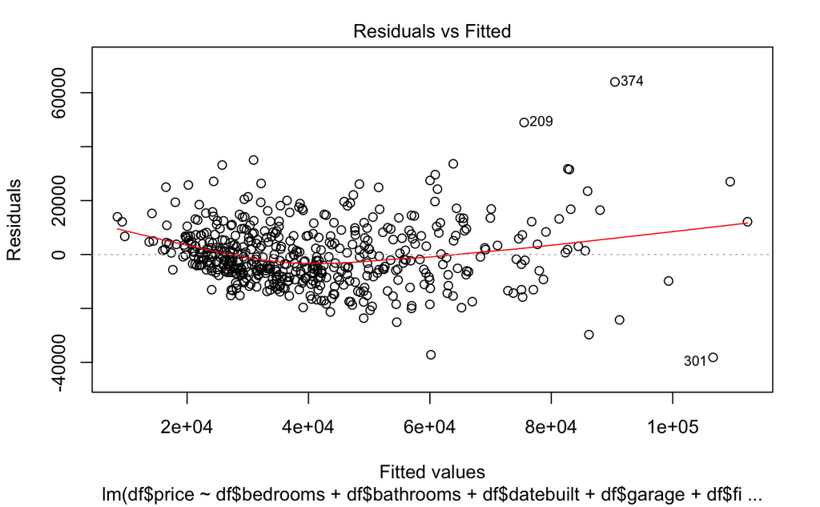

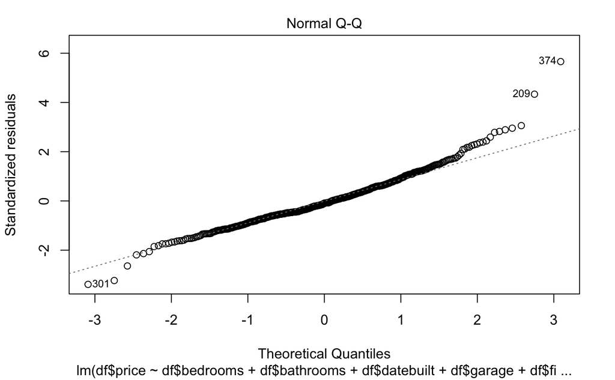

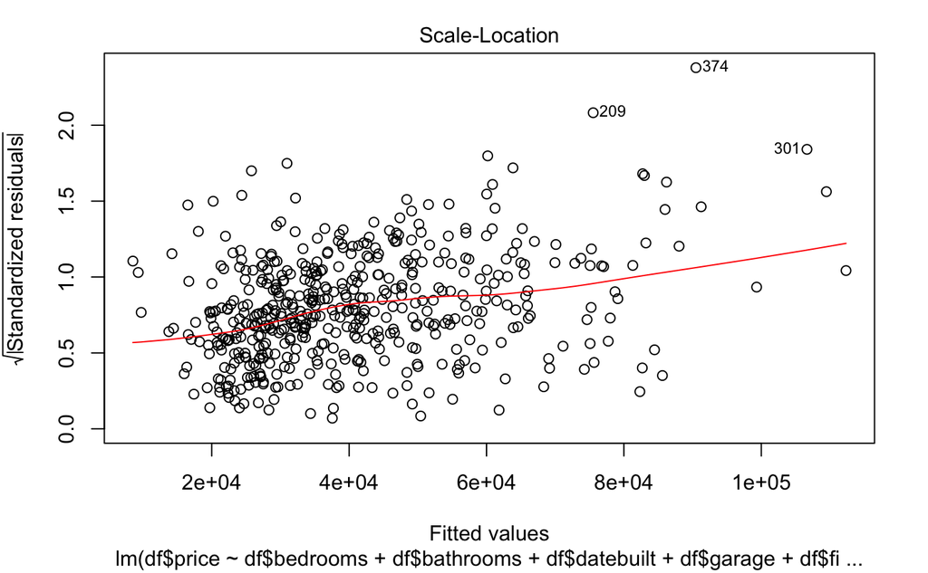

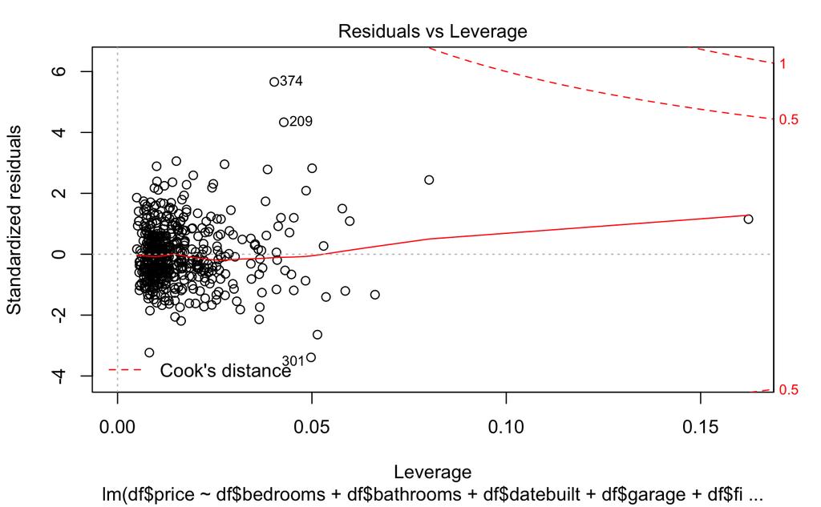

```r
plot(m)
```

```r
leverage.max <- 2*7/nrow(df)
print("In the Residuals vs Leverage diagram, the data after x = 0.028 are outliers")
```

```
[1] "In the Residuals vs Leverage diagram, the data after x = 0.028 are outliers"
```

### Question 2(b)

Attempt to improve the regression equation found in (a). Justify your decisions in constructing and carrying out the analysis.

```r
m1 <- step(m,direction = "backward")
```

```
Start:  AIC=9343.39
df$price ~ df$bedrooms + df$bathrooms + df$datebuilt + df$garage +
    df$fireplace + df$floorarea + df$detached

               Df  Sum of Sq        RSS    AIC
- df$bedrooms   1 1.1388e+08 6.5578e+10 9342.3
<none>                       6.5464e+10 9343.4
- df$bathrooms  1 3.9804e+08 6.5862e+10 9344.4
- df$fireplace  1 8.7433e+08 6.6339e+10 9348.0
- df$detached   1 4.2121e+09 6.9676e+10 9372.5
- df$datebuilt  1 7.1168e+09 7.2581e+10 9392.9
- df$garage     1 9.8904e+09 7.5355e+10 9411.6
- df$floorarea  1 3.7819e+10 1.0328e+11 9568.9

Step:  AIC=9342.26
df$price ~ df$bathrooms + df$datebuilt + df$garage + df$fireplace +
    df$floorarea + df$detached

               Df  Sum of Sq        RSS    AIC
<none>                       6.5578e+10 9342.3
- df$bathrooms  1 3.8265e+08 6.5961e+10 9343.2
- df$fireplace  1 8.6500e+08 6.6443e+10 9346.8
- df$detached   1 4.3063e+09 6.9884e+10 9372.0
- df$datebuilt  1 7.7124e+09 7.3290e+10 9395.7
- df$garage     1 1.0025e+10 7.5603e+10 9411.2
- df$floorarea  1 6.0089e+10 1.2567e+11 9664.8
```

```r
m11 <- lm(df$price~df$datebuilt+df$garage+df$fireplace+df$floorarea+df$detached)
summary(m11)
```

```
Call:
lm(formula = df$price ~ df$datebuilt + df$garage + df$fireplace +
    df$floorarea + df$detached)

Residuals:
   Min     1Q Median     3Q    Max
-37427  -7000  -1148   6312  62416

Coefficients:
               Estimate Std. Error t value Pr(>|t|)
(Intercept)  -260574.57   34441.44  -7.566 1.91e-13 ***
df$datebuilt     134.39      17.56   7.653 1.04e-13 ***
df$garage      10913.99    1273.30   8.571  < 2e-16 ***
df$fireplace   -3016.56    1228.15  -2.456   0.0144 *
df$floorarea     387.53      18.19  21.304  < 2e-16 ***
df$detached    13935.26    2317.15   6.014 3.53e-09 ***
---
Signif. codes:  0 '***' 0.001 '**' 0.01 '*' 0.05 '.' 0.1 ' ' 1

Residual standard error: 11570 on 493 degrees of freedom
Multiple R-squared:  0.6944,    Adjusted R-squared:  0.6913
F-statistic:   224 on 5 and 493 DF,  p-value: < 2.2e-16
```

```r
print("price=-260574.57+134.39*datebuilt+10913.99*garage-3016.56*fireplace+387.53*floorarea+13935.26*detached")
```

```
[1] "price=-260574.57+134.39*datebuilt+10913.99*garage-3016.56*fireplace+387.53*floorarea+13935.26*detached"
```

## Question 3

This is Exercise 11 in Chapter 9 of the Textbook [R].

### Question 3(a)

Using R and the [Milwaukee dataset](http://spatial.binghamton.edu/geog533/data/Milwaukee_Sales.csv) described in Section 1.9.2, construct a regression equation using housing sales price as the dependent variable, and number of bedrooms, lot size, finished square footage in the house, age of house, and number of bathrooms, as the independent variables. Investigate the importance of multicollinearity and outliers. Comment on the weaknesses of this specification, and on the results.

```r
url = "http://spatial.binghamton.edu/geog533/data/Milwaukee_Sales.csv"
df <- read.csv(url)
m <- lm(df$SalePrice~df$Bedrms+df$LotSize+df$FinSqft+df$Age+df$Baths)
summary(m)
```

```
Call:
lm(formula = df$SalePrice ~ df$Bedrms + df$LotSize + df$FinSqft +
    df$Age + df$Baths)

Residuals:
    Min      1Q  Median      3Q     Max
-243841  -29791    2824   28372  460759

Coefficients:
              Estimate Std. Error t value Pr(>|t|)
(Intercept)  2.624e+04  9.420e+03   2.786  0.00541 **
df$Bedrms   -2.876e+04  2.372e+03 -12.122  < 2e-16 ***
df$LotSize   3.580e+00  6.442e-01   5.557 3.26e-08 ***
df$FinSqft   1.007e+02  4.535e+00  22.210  < 2e-16 ***
df$Age      -1.306e+02  7.629e+01  -1.712  0.08711 .
df$Baths     2.302e+04  3.698e+03   6.225 6.29e-10 ***
---
Signif. codes:  0 '***' 0.001 '**' 0.01 '*' 0.05 '.' 0.1 ' ' 1

Residual standard error: 60990 on 1443 degrees of freedom
Multiple R-squared:  0.4867,    Adjusted R-squared:  0.4849
F-statistic: 273.6 on 5 and 1443 DF,  p-value: < 2.2e-16
```

```r
print("SalePrice=26240-28760*Bedrms+3.58*LotSize+100.7*FinSqft-130.6*Age+23020*Baths")
```

```
[1] "SalePrice=26240-28760*Bedrms+3.58*LotSize+100.7*FinSqft-130.6*Age+23020*Baths"
```

```r
print("The p-values of age is over 0.05 so that this variable should be deleted and this equation could express 48.67% of the relationship")
```

```
[1] "The p-values of age is over 0.05 so that this variable should be deleted and this equation could express 48.67% of the relationship"
```

```r
result <- anova(m)
s <- sum(result[1:5,3])
vif <- 1/(1-result[1:5,3]/s)
if(vif<5){
  print("There are not potential multicollinearity problems")
}else{
  print("There are potential multicollinearity problems")
}
```

```
the condition has length > 1 and only the first element will be used
```

```
[1] "There are not potential multicollinearity problems"
```

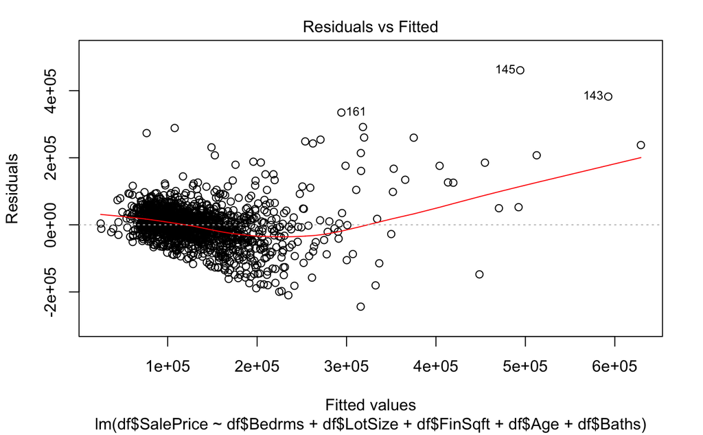

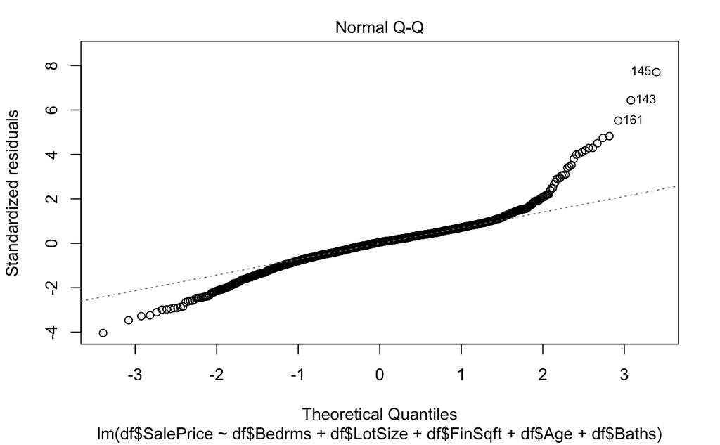

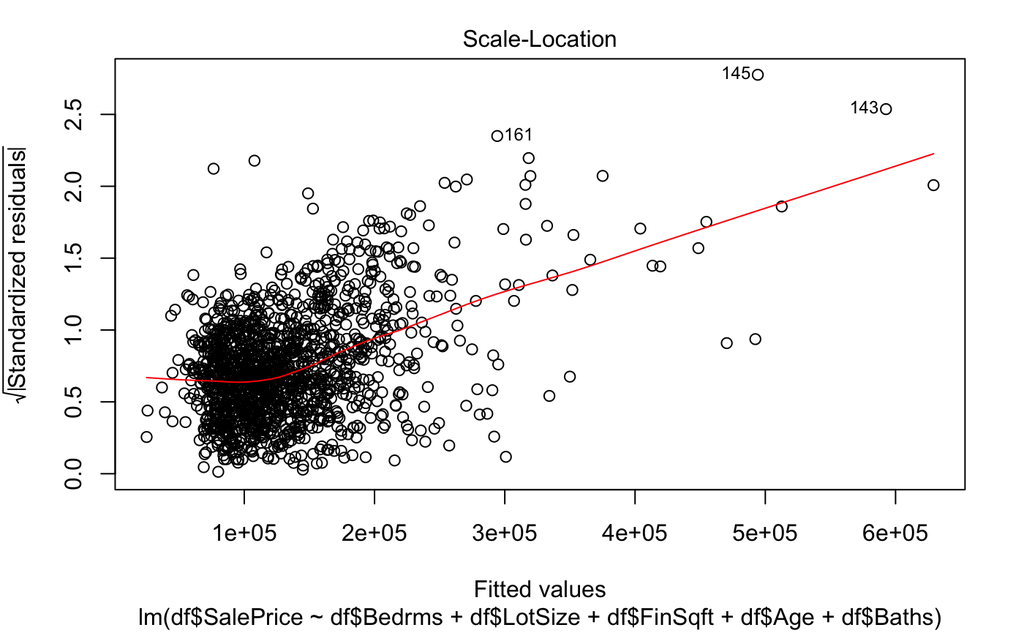

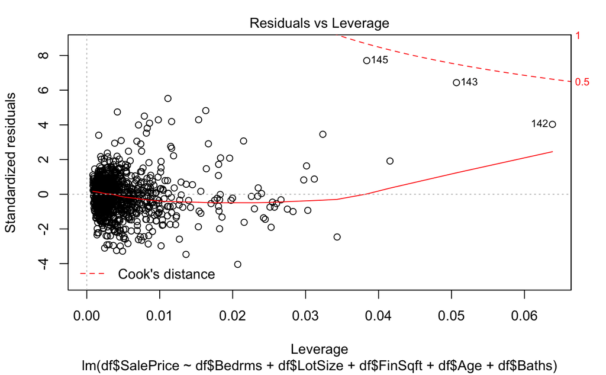

```r
plot(m)
```

```r
leverage.max <- 2*5/nrow(df)
print("In the Residuals vs Leverage diagram, the data after x = 0.006 are outliers")
```

```
[1] "In the Residuals vs Leverage diagram, the data after x = 0.006 are outliers"
```

### Question 3(b)

Attempt to improve the regression equation found in (a). Justify your decisions in constructing and carrying out the analysis.

```r
m1 <- step(m,direction = "backward")
```

```
Start:  AIC=31937.3
df$SalePrice ~ df$Bedrms + df$LotSize + df$FinSqft + df$Age +
    df$Baths

             Df  Sum of Sq        RSS   AIC
<none>                     5.3669e+12 31937
- df$Age      1 1.0901e+10 5.3778e+12 31938
- df$LotSize  1 1.1485e+11 5.4817e+12 31966
- df$Baths    1 1.4414e+11 5.5110e+12 31974
- df$Bedrms   1 5.4651e+11 5.9134e+12 32076
- df$FinSqft  1 1.8347e+12 7.2016e+12 32361
```

```r
m11 <- lm(df$SalePrice~df$Bedrms+df$LotSize+df$FinSqft+df$Baths)
summary(m11)
```

```
Call:
lm(formula = df$SalePrice ~ df$Bedrms + df$LotSize + df$FinSqft +
    df$Baths)

Residuals:
    Min      1Q  Median      3Q     Max
-246321  -29808    2642   29036  456835

Coefficients:
              Estimate Std. Error t value Pr(>|t|)
(Intercept)  1.544e+04  6.995e+03   2.206   0.0275 *
df$Bedrms   -2.870e+04  2.374e+03 -12.090  < 2e-16 ***
df$LotSize   4.058e+00  5.808e-01   6.987 4.28e-12 ***
df$FinSqft   9.849e+01  4.346e+00  22.659  < 2e-16 ***
df$Baths     2.401e+04  3.656e+03   6.568 7.08e-11 ***
---
Signif. codes:  0 '***' 0.001 '**' 0.01 '*' 0.05 '.' 0.1 ' ' 1

Residual standard error: 61030 on 1444 degrees of freedom
Multiple R-squared:  0.4857,    Adjusted R-squared:  0.4842
F-statistic: 340.9 on 4 and 1444 DF,  p-value: < 2.2e-16
```

```r
print("SalePrice=15440-28700*Bedrms+4.058*LotSize+98.49*FinSqft+24010*Baths")
```

```
[1] "SalePrice=15440-28700*Bedrms+4.058*LotSize+98.49*FinSqft+24010*Baths"
```